# Forecast Final Project

## BANA 4090 - Final Project - Sam Foley, Andrew Rose, Drew Louden, Bryce Dippold

### 1. Import Libaries and install if needed

```python
# import modules
import pandas as pd
import numpy as np
import matplotlib.pyplot as plt
from matplotlib import font_manager as fm
%matplotlib inline

from statsmodels.graphics import tsaplots

from statsmodels.tsa.api import SimpleExpSmoothing
from pmdarima import auto_arima

from tensorflow import keras

from sklearn.ensemble import IsolationForest
from sklearn.metrics import r2_score

from rich.table import Table

import warnings
warnings.filterwarnings('ignore')
```

### 2. Load dataset available through canvas

```python
df = pd.read_csv('WebVisits.csv')
```

### 3. Exploratory Data Analysis

- Data Dimension
- Data Types
- Summary Statistics
- Peak at start and end of dataframe

```python
# get the dimensions of the dataset
df.shape
```

```
(145063, 551)
```

```python
# data types
df.dtypes
```

```
Web_Page_Visited     object
2015-07-01          float64
2015-07-02          float64
2015-07-03          float64
2015-07-04          float64
                     ...
2016-12-27          float64
2016-12-28          float64
2016-12-29          float64
2016-12-30          float64
2016-12-31          float64
Length: 551, dtype: object
```

```python
# basic statistical analysis
df.describe()
```

|  | 2015-07-01 | 2015-07-02 | 2015-07-03 | 2015-07-04 | 2015-07-05 | 2015-07-06 | 2015-07-07 | 2015-07-08 | 2015-07-09 | 2015-07-10 | ... | 2016-12-22 | 2016-12-23 | 2016-12-24 | 2016-12-25 | 2016-12-26 | 2016-12-27 | 2016-12-28 | 2016-12-29 | 2016-12-30 | 2016-12-31 |
| --- | --- | --- | --- | --- | --- | --- | --- | --- | --- | --- | --- | --- | --- | --- | --- | --- | --- | --- | --- | --- | --- |
| count | 1.243230e+05 | 1.242470e+05 | 1.245190e+05 | 1.244090e+05 | 1.244040e+05 | 1.245800e+05 | 1.243990e+05 | 1.247690e+05 | 1.248190e+05 | 1.247210e+05 | ... | 1.412100e+05 | 1.414790e+05 | 1.418740e+05 | 1.413190e+05 | 1.411450e+05 | 1.413620e+05 | 1.412410e+05 | 1.412370e+05 | 1.414280e+05 | 1.415980e+05 |
| mean | 1.195857e+03 | 1.204004e+03 | 1.133676e+03 | 1.170437e+03 | 1.217769e+03 | 1.290273e+03 | 1.239137e+03 | 1.193092e+03 | 1.197992e+03 | 1.189651e+03 | ... | 1.394096e+03 | 1.377482e+03 | 1.393099e+03 | 1.523740e+03 | 1.679607e+03 | 1.678302e+03 | 1.633966e+03 | 1.684308e+03 | 1.467943e+03 | 1.478282e+03 |
| std | 7.275352e+04 | 7.421515e+04 | 6.961022e+04 | 7.257351e+04 | 7.379612e+04 | 8.054448e+04 | 7.576288e+04 | 6.820002e+04 | 7.149717e+04 | 7.214536e+04 | ... | 8.574880e+04 | 7.732794e+04 | 8.478533e+04 | 8.752210e+04 | 9.794534e+04 | 9.232482e+04 | 9.185831e+04 | 9.014266e+04 | 8.155481e+04 | 8.873567e+04 |
| min | 0.000000e+00 | 0.000000e+00 | 0.000000e+00 | 0.000000e+00 | 0.000000e+00 | 0.000000e+00 | 0.000000e+00 | 0.000000e+00 | 0.000000e+00 | 0.000000e+00 | ... | 0.000000e+00 | 0.000000e+00 | 0.000000e+00 | 0.000000e+00 | 0.000000e+00 | 0.000000e+00 | 0.000000e+00 | 0.000000e+00 | 0.000000e+00 | 0.000000e+00 |
| 25% | 1.300000e+01 | 1.300000e+01 | 1.200000e+01 | 1.300000e+01 | 1.400000e+01 | 1.100000e+01 | 1.300000e+01 | 1.300000e+01 | 1.400000e+01 | 1.400000e+01 | ... | 2.200000e+01 | 2.200000e+01 | 2.000000e+01 | 2.100000e+01 | 2.200000e+01 | 2.300000e+01 | 2.400000e+01 | 2.300000e+01 | 2.300000e+01 | 2.100000e+01 |
| 50% | 1.090000e+02 | 1.080000e+02 | 1.050000e+02 | 1.050000e+02 | 1.130000e+02 | 1.130000e+02 | 1.150000e+02 | 1.170000e+02 | 1.150000e+02 | 1.130000e+02 | ... | 1.490000e+02 | 1.430000e+02 | 1.320000e+02 | 1.450000e+02 | 1.600000e+02 | 1.620000e+02 | 1.630000e+02 | 1.600000e+02 | 1.540000e+02 | 1.360000e+02 |
| 75% | 5.240000e+02 | 5.190000e+02 | 5.040000e+02 | 4.870000e+02 | 5.400000e+02 | 5.550000e+02 | 5.510000e+02 | 5.540000e+02 | 5.490000e+02 | 5.450000e+02 | ... | 6.070000e+02 | 5.980000e+02 | 5.690000e+02 | 6.280000e+02 | 6.590000e+02 | 6.680000e+02 | 6.540000e+02 | 6.490000e+02 | 6.350000e+02 | 5.610000e+02 |
| max | 2.038124e+07 | 2.075219e+07 | 1.957397e+07 | 2.043964e+07 | 2.077211e+07 | 2.254467e+07 | 2.121089e+07 | 1.910791e+07 | 1.999385e+07 | 2.020182e+07 | ... | 2.420108e+07 | 2.253925e+07 | 2.505662e+07 | 2.586575e+07 | 2.834288e+07 | 2.691699e+07 | 2.702505e+07 | 2.607382e+07 | 2.436397e+07 | 2.614954e+07 |

8 rows × 550 columns

```python
# peek at the first few rows
df.head(5)
```

|  | Web_Page_Visited | 2015-07-01 | 2015-07-02 | 2015-07-03 | 2015-07-04 | 2015-07-05 | 2015-07-06 | 2015-07-07 | 2015-07-08 | 2015-07-09 | ... | 2016-12-22 | 2016-12-23 | 2016-12-24 | 2016-12-25 | 2016-12-26 | 2016-12-27 | 2016-12-28 | 2016-12-29 | 2016-12-30 | 2016-12-31 |
| --- | --- | --- | --- | --- | --- | --- | --- | --- | --- | --- | --- | --- | --- | --- | --- | --- | --- | --- | --- | --- | --- |
| 0 | 2NE1_zh.wikipedia.org_all-access_spider | 18.0 | 11.0 | 5.0 | 13.0 | 14.0 | 9.0 | 9.0 | 22.0 | 26.0 | ... | 32.0 | 63.0 | 15.0 | 26.0 | 14.0 | 20.0 | 22.0 | 19.0 | 18.0 | 20.0 |
| 1 | 2PM_zh.wikipedia.org_all-access_spider | 11.0 | 14.0 | 15.0 | 18.0 | 11.0 | 13.0 | 22.0 | 11.0 | 10.0 | ... | 17.0 | 42.0 | 28.0 | 15.0 | 9.0 | 30.0 | 52.0 | 45.0 | 26.0 | 20.0 |
| 2 | 3C_zh.wikipedia.org_all-access_spider | 1.0 | 0.0 | 1.0 | 1.0 | 0.0 | 4.0 | 0.0 | 3.0 | 4.0 | ... | 3.0 | 1.0 | 1.0 | 7.0 | 4.0 | 4.0 | 6.0 | 3.0 | 4.0 | 17.0 |
| 3 | 4minute_zh.wikipedia.org_all-access_spider | 35.0 | 13.0 | 10.0 | 94.0 | 4.0 | 26.0 | 14.0 | 9.0 | 11.0 | ... | 32.0 | 10.0 | 26.0 | 27.0 | 16.0 | 11.0 | 17.0 | 19.0 | 10.0 | 11.0 |
| 4 | 52_Hz_I_Love_You_zh.wikipedia.org_all-access_s... | NaN | NaN | NaN | NaN | NaN | NaN | NaN | NaN | NaN | ... | 48.0 | 9.0 | 25.0 | 13.0 | 3.0 | 11.0 | 27.0 | 13.0 | 36.0 | 10.0 |

5 rows × 551 columns

```python
# peek at the last few rows
df.tail(5)
```

|  | Web_Page_Visited | 2015-07-01 | 2015-07-02 | 2015-07-03 | 2015-07-04 | 2015-07-05 | 2015-07-06 | 2015-07-07 | 2015-07-08 | 2015-07-09 | ... | 2016-12-22 | 2016-12-23 | 2016-12-24 | 2016-12-25 | 2016-12-26 | 2016-12-27 | 2016-12-28 | 2016-12-29 | 2016-12-30 | 2016-12-31 |
| --- | --- | --- | --- | --- | --- | --- | --- | --- | --- | --- | --- | --- | --- | --- | --- | --- | --- | --- | --- | --- | --- |
| 145058 | Underworld_(serie_de_películas)_es.wikipedia.o... | NaN | NaN | NaN | NaN | NaN | NaN | NaN | NaN | NaN | ... | NaN | NaN | NaN | NaN | 13.0 | 12.0 | 13.0 | 3.0 | 5.0 | 10.0 |
| 145059 | Resident_Evil:_Capítulo_Final_es.wikipedia.org... | NaN | NaN | NaN | NaN | NaN | NaN | NaN | NaN | NaN | ... | NaN | NaN | NaN | NaN | NaN | NaN | NaN | NaN | NaN | NaN |
| 145060 | Enamorándome_de_Ramón_es.wikipedia.org_all-acc... | NaN | NaN | NaN | NaN | NaN | NaN | NaN | NaN | NaN | ... | NaN | NaN | NaN | NaN | NaN | NaN | NaN | NaN | NaN | NaN |
| 145061 | Hasta_el_último_hombre_es.wikipedia.org_all-ac... | NaN | NaN | NaN | NaN | NaN | NaN | NaN | NaN | NaN | ... | NaN | NaN | NaN | NaN | NaN | NaN | NaN | NaN | NaN | NaN |
| 145062 | Francisco_el_matemático_(serie_de_televisión_d... | NaN | NaN | NaN | NaN | NaN | NaN | NaN | NaN | NaN | ... | NaN | NaN | NaN | NaN | NaN | NaN | NaN | NaN | NaN | NaN |

5 rows × 551 columns

### 4. Data Pre-Processing and Wrangling

- Check for Missing Values and fill them or remove them if needed
- Get unique values
- Pivot table from wide format to long format using melt()
- Make Date as index
- Plot Average and total Number of Visits and write down your observations
- Reshape data to analyze time series through plotting day, per week day, month, and year
- Plot Visits per weekday and write down your observations
- Plot visits per year and write down your observations
- Get top 5 most visited pages

### Check for Missing Values and fill them or remove them if needed

```python
# check for missing value
df.isna().sum()
```

```
Web_Page_Visited        0
2015-07-01          20740
2015-07-02          20816
2015-07-03          20544
2015-07-04          20654
                    ...
2016-12-27           3701
2016-12-28           3822
2016-12-29           3826
2016-12-30           3635
2016-12-31           3465
Length: 551, dtype: int64
```

```python
# there are lots of missing values - Let's take a broader look
df
```

|  | Web_Page_Visited | 2015-07-01 | 2015-07-02 | 2015-07-03 | 2015-07-04 | 2015-07-05 | 2015-07-06 | 2015-07-07 | 2015-07-08 | 2015-07-09 | ... | 2016-12-22 | 2016-12-23 | 2016-12-24 | 2016-12-25 | 2016-12-26 | 2016-12-27 | 2016-12-28 | 2016-12-29 | 2016-12-30 | 2016-12-31 |
| --- | --- | --- | --- | --- | --- | --- | --- | --- | --- | --- | --- | --- | --- | --- | --- | --- | --- | --- | --- | --- | --- |
| 0 | 2NE1_zh.wikipedia.org_all-access_spider | 18.0 | 11.0 | 5.0 | 13.0 | 14.0 | 9.0 | 9.0 | 22.0 | 26.0 | ... | 32.0 | 63.0 | 15.0 | 26.0 | 14.0 | 20.0 | 22.0 | 19.0 | 18.0 | 20.0 |
| 1 | 2PM_zh.wikipedia.org_all-access_spider | 11.0 | 14.0 | 15.0 | 18.0 | 11.0 | 13.0 | 22.0 | 11.0 | 10.0 | ... | 17.0 | 42.0 | 28.0 | 15.0 | 9.0 | 30.0 | 52.0 | 45.0 | 26.0 | 20.0 |
| 2 | 3C_zh.wikipedia.org_all-access_spider | 1.0 | 0.0 | 1.0 | 1.0 | 0.0 | 4.0 | 0.0 | 3.0 | 4.0 | ... | 3.0 | 1.0 | 1.0 | 7.0 | 4.0 | 4.0 | 6.0 | 3.0 | 4.0 | 17.0 |
| 3 | 4minute_zh.wikipedia.org_all-access_spider | 35.0 | 13.0 | 10.0 | 94.0 | 4.0 | 26.0 | 14.0 | 9.0 | 11.0 | ... | 32.0 | 10.0 | 26.0 | 27.0 | 16.0 | 11.0 | 17.0 | 19.0 | 10.0 | 11.0 |
| 4 | 52_Hz_I_Love_You_zh.wikipedia.org_all-access_s... | NaN | NaN | NaN | NaN | NaN | NaN | NaN | NaN | NaN | ... | 48.0 | 9.0 | 25.0 | 13.0 | 3.0 | 11.0 | 27.0 | 13.0 | 36.0 | 10.0 |
| ... | ... | ... | ... | ... | ... | ... | ... | ... | ... | ... | ... | ... | ... | ... | ... | ... | ... | ... | ... | ... | ... |
| 145058 | Underworld_(serie_de_películas)_es.wikipedia.o... | NaN | NaN | NaN | NaN | NaN | NaN | NaN | NaN | NaN | ... | NaN | NaN | NaN | NaN | 13.0 | 12.0 | 13.0 | 3.0 | 5.0 | 10.0 |
| 145059 | Resident_Evil:_Capítulo_Final_es.wikipedia.org... | NaN | NaN | NaN | NaN | NaN | NaN | NaN | NaN | NaN | ... | NaN | NaN | NaN | NaN | NaN | NaN | NaN | NaN | NaN | NaN |
| 145060 | Enamorándome_de_Ramón_es.wikipedia.org_all-acc... | NaN | NaN | NaN | NaN | NaN | NaN | NaN | NaN | NaN | ... | NaN | NaN | NaN | NaN | NaN | NaN | NaN | NaN | NaN | NaN |
| 145061 | Hasta_el_último_hombre_es.wikipedia.org_all-ac... | NaN | NaN | NaN | NaN | NaN | NaN | NaN | NaN | NaN | ... | NaN | NaN | NaN | NaN | NaN | NaN | NaN | NaN | NaN | NaN |
| 145062 | Francisco_el_matemático_(serie_de_televisión_d... | NaN | NaN | NaN | NaN | NaN | NaN | NaN | NaN | NaN | ... | NaN | NaN | NaN | NaN | NaN | NaN | NaN | NaN | NaN | NaN |

145063 rows × 551 columns

```python
# there are alot of missing values, but we there is no way to fill them with confidence
# none of the filling techniques can apply as it is all user intentions
# we have a large dataste, as such we can afford to delete all NaNs.
# df = df.dropna()
df.dropna(inplace=True)
```

```python
# verify no missing value
df.isna().sum()
```

```
Web_Page_Visited    0
2015-07-01          0
2015-07-02          0
2015-07-03          0
2015-07-04          0
                   ..
2016-12-27          0
2016-12-28          0
2016-12-29          0
2016-12-30          0
2016-12-31          0
Length: 551, dtype: int64
```

### Get unique values

```python
# check number of unique pages visited
len(df.Web_Page_Visited.str.lower().unique())
```

```
117235
```

### Pivot table from wide format to long format using melt()

```python
# to make statistical analysis easier, reshape the data from wide format to long format using melt()
df_Long = pd.melt(df, id_vars=['Web_Page_Visited'], var_name = 'Date', value_name = 'Visits')
```

```python
# peek at head
df_Long.head(5)
```

|  | Web_Page_Visited | Date | Visits |
| --- | --- | --- | --- |
| 0 | 2NE1_zh.wikipedia.org_all-access_spider | 2015-07-01 | 18.0 |
| 1 | 2PM_zh.wikipedia.org_all-access_spider | 2015-07-01 | 11.0 |
| 2 | 3C_zh.wikipedia.org_all-access_spider | 2015-07-01 | 1.0 |
| 3 | 4minute_zh.wikipedia.org_all-access_spider | 2015-07-01 | 35.0 |
| 4 | 5566_zh.wikipedia.org_all-access_spider | 2015-07-01 | 12.0 |

### Make Date as index

```python
# Make Date as index
df_Long['Date'] = pd.DatetimeIndex(df_Long['Date'])
df_Long
```

|  | Web_Page_Visited | Date | Visits |
| --- | --- | --- | --- |
| 0 | 2NE1_zh.wikipedia.org_all-access_spider | 2015-07-01 | 18.0 |
| 1 | 2PM_zh.wikipedia.org_all-access_spider | 2015-07-01 | 11.0 |
| 2 | 3C_zh.wikipedia.org_all-access_spider | 2015-07-01 | 1.0 |
| 3 | 4minute_zh.wikipedia.org_all-access_spider | 2015-07-01 | 35.0 |
| 4 | 5566_zh.wikipedia.org_all-access_spider | 2015-07-01 | 12.0 |
| ... | ... | ... | ... |
| 64502345 | Chichén_Itzá_es.wikipedia.org_all-access_spider | 2016-12-31 | 19.0 |
| 64502346 | Fecundación_es.wikipedia.org_all-access_spider | 2016-12-31 | 8.0 |
| 64502347 | Gran_Hermano_VIP_(España)_es.wikipedia.org_all... | 2016-12-31 | 43.0 |
| 64502348 | Modelo_atómico_de_Thomson_es.wikipedia.org_all... | 2016-12-31 | 4.0 |
| 64502349 | Copa_América_2019_es.wikipedia.org_all-access_... | 2016-12-31 | 8.0 |

64502350 rows × 3 columns

### Plot Average and total Number of Visits

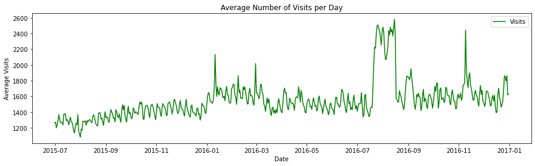

```python
# plot average number of visits
temp = df_Long.groupby('Date')['Visits'].mean()
plt.figure(figsize=(15,4))
plt.xlabel('Date')
plt.ylabel('Average Visits')
plt.title('Average Number of Visits per Day')
plt.plot(temp, label='Visits', color='Green')
plt.legend()
plt.show()
```

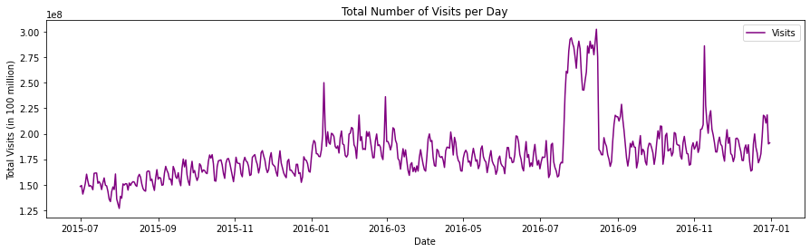

```python
# plot total number of visits
temp = df_Long.groupby('Date')['Visits'].sum()
plt.figure(figsize=(15,4))
plt.xlabel('Date')
plt.ylabel('Total Visits (in 100 million)')
plt.title('Total Number of Visits per Day')
plt.plot(temp, label='Visits', color='Purple')
plt.legend()
plt.show()
```

This plot looks relatively the same as the one before it.

### Reshape data to analyze time series through plotting day, per weekday, month, and year

```python
# for further analysis, web traffic can be analyzed per day, per week, per month, or even per weekdays or weekends
# make another copy of the dataframe
df_Analysis = df_Long
df_Analysis['year']=df_Analysis.Date.dt.year
df_Analysis['month']=df_Analysis.Date.dt.month
df_Analysis['day']=df_Analysis.Date.dt.day

# peek at new dataframe
df_Analysis.head()
```

|  | Web_Page_Visited | Date | Visits | year | month | day |
| --- | --- | --- | --- | --- | --- | --- |
| 0 | 2NE1_zh.wikipedia.org_all-access_spider | 2015-07-01 | 18.0 | 2015 | 7 | 1 |
| 1 | 2PM_zh.wikipedia.org_all-access_spider | 2015-07-01 | 11.0 | 2015 | 7 | 1 |
| 2 | 3C_zh.wikipedia.org_all-access_spider | 2015-07-01 | 1.0 | 2015 | 7 | 1 |
| 3 | 4minute_zh.wikipedia.org_all-access_spider | 2015-07-01 | 35.0 | 2015 | 7 | 1 |
| 4 | 5566_zh.wikipedia.org_all-access_spider | 2015-07-01 | 12.0 | 2015 | 7 | 1 |

```python
# get week days
df_Analysis['weekday'] = df_Analysis['Date'].apply(lambda x: x.weekday())
```

```python
# switch day numbers to names
df_Analysis['weekday#'] = df_Analysis['weekday']
df_Analysis['weekday'].replace(0, '01 - Monday', inplace=True)
df_Analysis['weekday'].replace(1, '02 - Tuesday', inplace=True)
df_Analysis['weekday'].replace(2, '03 - Wednesday', inplace=True)
df_Analysis['weekday'].replace(3, '04 - Thursday', inplace=True)
df_Analysis['weekday'].replace(4, '05 - Friday', inplace=True)
df_Analysis['weekday'].replace(5, '06 - Saturday', inplace=True)
df_Analysis['weekday'].replace(6, '07 - Sunday', inplace=True)

# peek at dataframe
df_Analysis.head()
```

|  | Web_Page_Visited | Date | Visits | year | month | day | weekday | weekday# |
| --- | --- | --- | --- | --- | --- | --- | --- | --- |
| 0 | 2NE1_zh.wikipedia.org_all-access_spider | 2015-07-01 | 18.0 | 2015 | 7 | 1 | 03 - Wednesday | 2 |
| 1 | 2PM_zh.wikipedia.org_all-access_spider | 2015-07-01 | 11.0 | 2015 | 7 | 1 | 03 - Wednesday | 2 |
| 2 | 3C_zh.wikipedia.org_all-access_spider | 2015-07-01 | 1.0 | 2015 | 7 | 1 | 03 - Wednesday | 2 |
| 3 | 4minute_zh.wikipedia.org_all-access_spider | 2015-07-01 | 35.0 | 2015 | 7 | 1 | 03 - Wednesday | 2 |
| 4 | 5566_zh.wikipedia.org_all-access_spider | 2015-07-01 | 12.0 | 2015 | 7 | 1 | 03 - Wednesday | 2 |

```python
# get visits by week day
df_day = df_Analysis[["weekday", "Visits"]].groupby(["weekday"])['Visits'].mean().reset_index()
df_day.head(7)
```

|  | weekday | Visits |
| --- | --- | --- |
| 0 | 01 - Monday | 1636.712609 |
| 1 | 02 - Tuesday | 1576.101825 |
| 2 | 03 - Wednesday | 1555.724440 |
| 3 | 04 - Thursday | 1518.109423 |
| 4 | 05 - Friday | 1468.359327 |
| 5 | 06 - Saturday | 1472.115170 |
| 6 | 07 - Sunday | 1592.077166 |

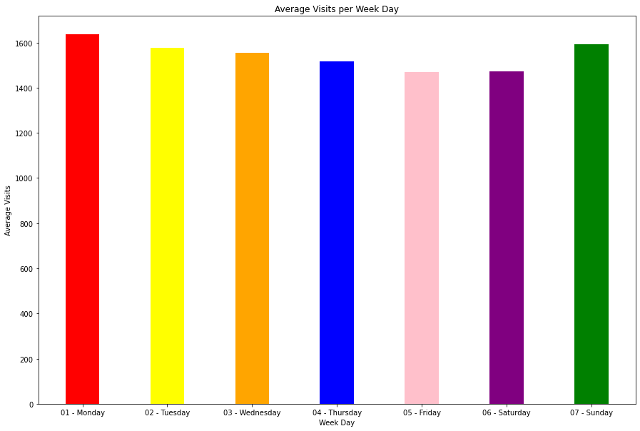

```python
# plot average visits per week day
fig = plt.figure(figsize = (15,10))
colors = ['Red', 'Yellow', 'Orange', 'Blue', 'Pink', 'Purple', 'Green']
# creating the bar plot
plt.bar(df_day['weekday'], df_day['Visits'], color = colors, width = 0.4)
plt.xlabel("Week Day")
plt.ylabel("Average Visits")
plt.title("Average Visits per Week Day")
plt.show()
```

It looks as though there are not outliers in which day gets the most traffic. Monday has the most average visits, but not by much, while Friday has the least average visits.

### Plot visits per month

```python
# get visits per month
df_month = df_Analysis[["month", "Visits"]].groupby(["month"])['Visits'].mean().reset_index()
df_month.head(12)
```

|  | month | Visits |
| --- | --- | --- |
| 0 | 1 | 1630.767939 |
| 1 | 2 | 1645.040631 |
| 2 | 3 | 1516.320286 |
| 3 | 4 | 1543.546594 |
| 4 | 5 | 1487.740055 |
| 5 | 6 | 1512.167394 |
| 6 | 7 | 1526.058843 |
| 7 | 8 | 1638.443462 |
| 8 | 9 | 1487.120464 |
| 9 | 10 | 1508.751246 |
| 10 | 11 | 1575.023861 |
| 11 | 12 | 1506.197597 |

```python
# change months from numeric to full name
df_month['month'] = pd.to_datetime(df_month['month'], format='%m').dt.month_name()
df_month.head(12)
```

|  | month | Visits |
| --- | --- | --- |
| 0 | January | 1630.767939 |
| 1 | February | 1645.040631 |
| 2 | March | 1516.320286 |
| 3 | April | 1543.546594 |
| 4 | May | 1487.740055 |
| 5 | June | 1512.167394 |
| 6 | July | 1526.058843 |
| 7 | August | 1638.443462 |
| 8 | September | 1487.120464 |
| 9 | October | 1508.751246 |
| 10 | November | 1575.023861 |
| 11 | December | 1506.197597 |

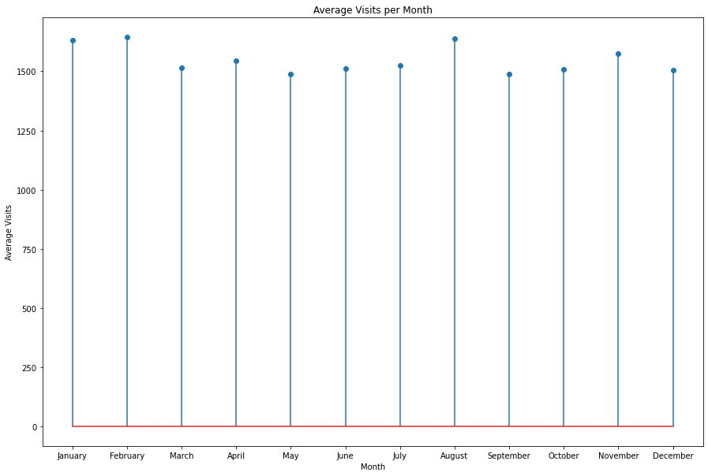

```python
# plot average visits per month
fig = plt.figure(figsize = (15, 10))
colors = ['Red', 'Yellow', 'Orange', 'Blue', 'Grey', 'Teal', 'Magenta', 'Black', 'Brown', 'Pink', 'Purple', 'Green']
# creating the bar plot
plt.stem(df_month['month'], df_month['Visits'])
plt.xlabel("Month")
plt.ylabel("Average Visits")
plt.title("Average Visits per Month")
plt.show()
```

It looks like the top 3 months for average visits are February, August, and January. There are also no huge outliers.

### Plot visits per year

```python
# get yearly visits
df_year = df_Analysis[["year", "Visits"]].groupby(["year"])['Visits'].mean().reset_index()
df_year.head()
```

|  | year | Visits |
| --- | --- | --- |
| 0 | 2015 | 1367.628469 |
| 1 | 2016 | 1634.612751 |

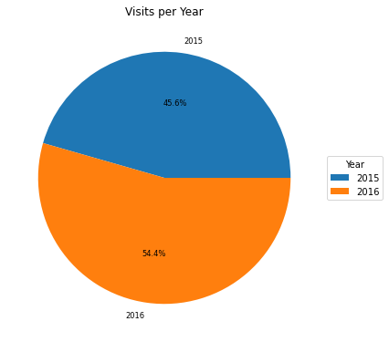

```python
# plot yearly visits
fig = plt.figure(1, figsize=(6,6))
ax = fig.add_axes([0.1, 0.1, 0.8, 0.8])
plt.title('Visits per Year')

labels = df_year['year']
pieces = df_year['Visits']

patches, texts, autotexts = ax.pie(pieces, labels=labels, autopct= '%1.1f%%')

ax.legend(labels, title="Year", loc="center left", bbox_to_anchor=(1, 0, 0.5, 1))

proptease = fm.FontProperties()
proptease.set_size('small')
plt.setp(autotexts, fontproperties=proptease)
plt.setp(texts, fontproperties=proptease)

plt.show()
```

### Get Top 5 most visited pages

```python
# get top 5 performer pages
df_Top5 = df_Long.groupby('Web_Page_Visited')['Visits'].sum().reset_index()
list_Top5 = df_Top5.nlargest(5, 'Visits')['Web_Page_Visited'].tolist()
```

```python
# peek at list
list_Top5
```

```
['Main_Page_en.wikipedia.org_all-access_all-agents',
 'Main_Page_en.wikipedia.org_desktop_all-agents',
 'Main_Page_en.wikipedia.org_mobile-web_all-agents',
 'Wikipedia:Hauptseite_de.wikipedia.org_all-access_all-agents',
 'Special:Search_en.wikipedia.org_all-access_all-agents']
```

```python
# get a dataframe with top 5 using list
top5_pages_df = df_Top5[df_Top5['Web_Page_Visited'].isin(list_Top5)]
top5_pages_df
```

|  | Web_Page_Visited | Visits |
| --- | --- | --- |
| 46048 | Main_Page_en.wikipedia.org_all-access_all-agents | 1.206618e+10 |
| 46050 | Main_Page_en.wikipedia.org_desktop_all-agents | 8.774497e+09 |
| 46051 | Main_Page_en.wikipedia.org_mobile-web_all-agents | 3.153985e+09 |
| 64828 | Special:Search_en.wikipedia.org_all-access_all... | 1.304079e+09 |
| 73225 | Wikipedia:Hauptseite_de.wikipedia.org_all-acce... | 1.603934e+09 |

```python
# reduce visits to millions of visits
top5_pages_df.loc[:, ('Visits')] = top5_pages_df['Visits']/1000000
top5_pages_df
```

|  | Web_Page_Visited | Visits |
| --- | --- | --- |
| 46048 | Main_Page_en.wikipedia.org_all-access_all-agents | 12066.181102 |
| 46050 | Main_Page_en.wikipedia.org_desktop_all-agents | 8774.497458 |
| 46051 | Main_Page_en.wikipedia.org_mobile-web_all-agents | 3153.984882 |
| 64828 | Special:Search_en.wikipedia.org_all-access_all... | 1304.079353 |
| 73225 | Wikipedia:Hauptseite_de.wikipedia.org_all-acce... | 1603.934248 |

### 5. Detect and handle Outliers

- reshape dataframe
- set date as index
- plot visits of top pages to see outliers
- add outlier indicator for plotting purposes
- Plot time series showing outliers
- Create function that calculates all components of Box Plot
- handle outliers by switching them with the median value
- plot time series with filled misisng values
- remove outlier column

### Reshape Dataframe

```python
# time series of page with maximum views
df_top_pages = df_Long[df_Long.Web_Page_Visited == list_Top5[0]]
df_top_pages.loc[:, ('Visits')] = df_top_pages['Visits'].div(1000000).round(2)
df_top_pages_final = df_top_pages[['Date', 'Visits']]
df_top_pages_final.head()
```

|  | Date | Visits |
| --- | --- | --- |
| 30279 | 2015-07-01 | 20.38 |
| 147556 | 2015-07-02 | 20.75 |
| 264833 | 2015-07-03 | 19.57 |
| 382110 | 2015-07-04 | 20.44 |
| 499387 | 2015-07-05 | 20.77 |

### Set Date as Index

```python
# set index
df_top_pages_final = df_top_pages_final.set_index('Date')
df_top_pages_final.head()
```

| Date | Visits |
| --- | --- |
| 2015-07-01 | 20.38 |
| 2015-07-02 | 20.75 |
| 2015-07-03 | 19.57 |
| 2015-07-04 | 20.44 |
| 2015-07-05 | 20.77 |

### Plot visits of top pages to see outliers

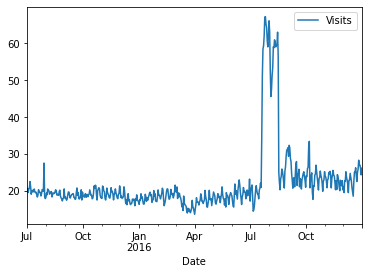

```python
#plot visits of top pages
df_top_pages_final.plot()
```

### Add outlier indicator for plotting purposes

```python
# adding outliers indicator for plotting purposes
isolation_forest_model = IsolationForest(contamination=0.05)
isolation_forest_model.fit(df_top_pages_final)
df_top_pages_final['Outlier'] = isolation_forest_model.predict(df_top_pages_final)
df_top_pages_final
```

| Date | Visits | Outlier |
| --- | --- | --- |
| 2015-07-01 | 20.38 | 1 |
| 2015-07-02 | 20.75 | 1 |
| 2015-07-03 | 19.57 | 1 |
| 2015-07-04 | 20.44 | 1 |
| 2015-07-05 | 20.77 | 1 |
| ... | ... | ... |
| 2016-12-27 | 26.92 | 1 |
| 2016-12-28 | 27.03 | 1 |
| 2016-12-29 | 26.07 | 1 |
| 2016-12-30 | 24.36 | 1 |
| 2016-12-31 | 26.15 | 1 |

550 rows × 2 columns

```python
# peek at last few pages
df_top_pages_final.tail(5)
```

| Date | Visits | Outlier |
| --- | --- | --- |
| 2016-12-27 | 26.92 | 1 |
| 2016-12-28 | 27.03 | 1 |
| 2016-12-29 | 26.07 | 1 |
| 2016-12-30 | 24.36 | 1 |
| 2016-12-31 | 26.15 | 1 |

### Plot Time series showing outliers

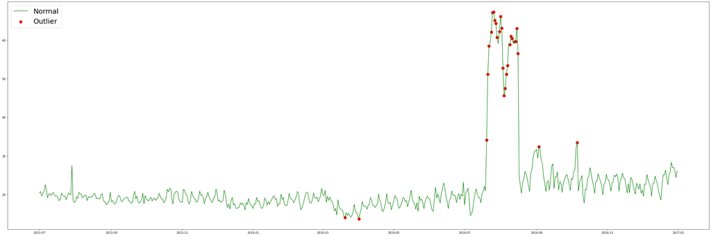

```python
fig, ax= plt.subplots(figsize=(45,15))
df_Outlier = df_top_pages_final.loc[df_top_pages_final['Outlier'] == -1].copy()
ax.plot(df_top_pages_final.index, df_top_pages_final['Visits'], color='green', label = 'Normal')
plt.scatter(df_Outlier.index, df_Outlier['Visits'], color = 'red', s=100, label = 'Outlier')
plt.legend(loc=2, prop={'size':25})
plt.show()
```

### Use Box Plot to verify outliers

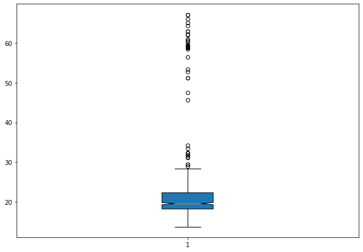

```python
# box plot to check outliers
fig, ax = plt.subplots(figsize=(10,7))
ax.boxplot(df_top_pages_final['Visits'], notch = True, vert=True, patch_artist=True)
plt.show()
```

### Create Function that calculates all components of Box Plot:

- mean, median, min_value, max_value, quartile_1, quartile_3, interquartile range
- Lower and Upper Outlier limits

```python
# Calculate all components of box plot to calculate the values of upper and lower limits of outliers
def get_summary_statistics(dataset):
    mean = np.round(np.mean(dataset),2)
    median = np.round(np.median(dataset), 2)
    min_value = np.round(dataset.min(), 2)
    max_value = np.round(dataset.max(), 2)
    quartile_1 = np.round(dataset.quantile(0.25), 2)
    quartile_3 = np.round(dataset.quantile(0.75), 2)
    #Interquartile range
    iqr = np.round(quartile_3 - quartile_1, 2)
    #Outliers
    lower_outlier_Less = quartile_1 - 1.5*iqr
    upper_outlier_Greater = quartile_3 + 1.5*iqr

    print('Min: %s' % min_value)
    print('Mean: %s' % mean)
    print('Max: %s' % max_value)
    print('25th percentile: %s' % quartile_1)
    print('Median: %s' % median)
    print('75th percentile: %s' % quartile_3)
    print('Interquartile Range (IQR): %s' % iqr)
    print('Lower Outlier: %s' % lower_outlier_Less)
    print('Upper Outlier: %s' % upper_outlier_Greater)

    return (lower_outlier_Less, upper_outlier_Greater)
```

```python
# Get Outlier Limits
LowerOut, UpperOut = get_summary_statistics(df_top_pages_final['Visits'])
```

```
Min: 13.66
Mean: 21.94
Max: 67.26
25th percentile: 18.1
Median: 19.45
75th percentile: 22.22
Interquartile Range (IQR): 4.12
Lower Outlier: 11.920000000000002
Upper Outlier: 28.4
```

### Handle Outliers by switching them with the median value

```python
# Create conditions for both upper and lower limits
df_NoOut = df_top_pages_final

#Remove the outliers and replace them with the median
median = float(df_NoOut['Visits'].median())
df_NoOut['Visits'] = np.where(df_NoOut['Visits'] >= UpperOut, median, df_NoOut['Visits'])
df_NoOut['Visits'] = np.where(df_NoOut['Visits'] <= LowerOut, median, df_NoOut['Visits'])
```

### Plot time series with filled missing values

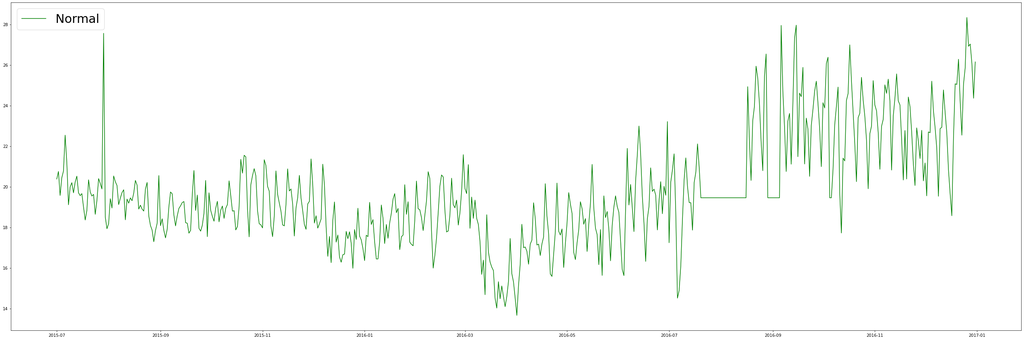

```python
# Plot time series with filled missing values
fig, ax = plt.subplots(figsize=(45,15))
ax.plot(df_NoOut.index, df_NoOut['Visits'], color='green', label= "Normal")
plt.legend(loc=2, prop={'size': 30})
plt.show()
```

### Remove Outlier column

```python
# Remove Outlier Column
df_NoOut = df_NoOut.drop('Outlier', axis=1)
df_NoOut.head(5)
```

| Date | Visits |
| --- | --- |
| 2015-07-01 | 20.38 |
| 2015-07-02 | 20.75 |
| 2015-07-03 | 19.57 |
| 2015-07-04 | 20.44 |
| 2015-07-05 | 20.77 |

## 6. Split data into training and test to prepare data for modelling, check its shape, and peek at sets

```python
# Split data into training and test to prepare data for modelling
df_train = df_NoOut[:'2016-09']
df_test = df_NoOut['2016-10':]
```

```python
df_train.tail(10)
```

| Date | Visits |
| --- | --- |
| 2016-09-21 | 23.38 |
| 2016-09-22 | 22.83 |
| 2016-09-23 | 20.51 |
| 2016-09-24 | 23.02 |
| 2016-09-25 | 23.81 |
| 2016-09-26 | 24.71 |
| 2016-09-27 | 25.20 |
| 2016-09-28 | 24.11 |
| 2016-09-29 | 22.86 |
| 2016-09-30 | 20.99 |

```python
df_test.head(5)
```

| Date | Visits |
| --- | --- |
| 2016-10-01 | 24.140 |
| 2016-10-02 | 23.880 |
| 2016-10-03 | 26.070 |
| 2016-10-04 | 26.380 |
| 2016-10-05 | 19.455 |

```python
print(df_train.shape)
print(df_test.shape)
```

```
(458, 1)
(92, 1)
```

# 7. Check and plot Correlation and Partial Correlation and Write down your observations

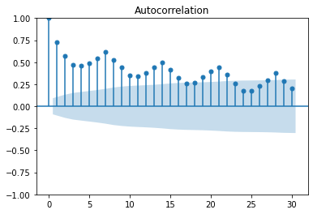

```python
# Check correlation between the training values how correlated with each other they are.
fig = tsaplots.plot_acf(df_train['Visits'], lags=30)
plt.show()
```

There is a strong positive correlation within the frst 10 ticks. As we get to the middle of the pack the correlation becomes less signifacnt with a slight rise form 12-14. Any bar above the blue shaded region should be assumed as statistically significant.

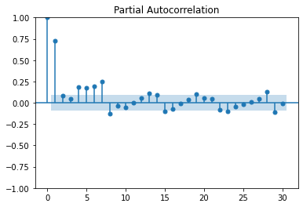

```python
# Check partial correlation between the training values.
fig = tsaplots.plot_pacf(df_train['Visits'], lags=30)
plt.show()
```

From what the plot shows us, there is correlation in the beginning but as we go up to the higher numbers there is no real correlation and no statistical signifiance.

# 8. Create three time series models to forecast number of future visits

- Exponential Smoothing Model
- Auto Arima
- CNN1D
- For each model Prepare dataset, fit, test, forecast, plot result, and calculate RMSE

```python
# Create List to jold all forecasting accuracy results
rmse_values = []
```

# Exponential Smoothing

```python
# Train Model
exp_smoothing_model = SimpleExpSmoothing(df_train)
exp_smoothing_result = exp_smoothing_model.fit(smoothing_level=0.5, optimized=True)
```

```python
#Predict Values
exp_smoothing_prediction = exp_smoothing_result.predict(start=df_train[-30:-29].index[0], end=df_train[-1:].index[0])
```

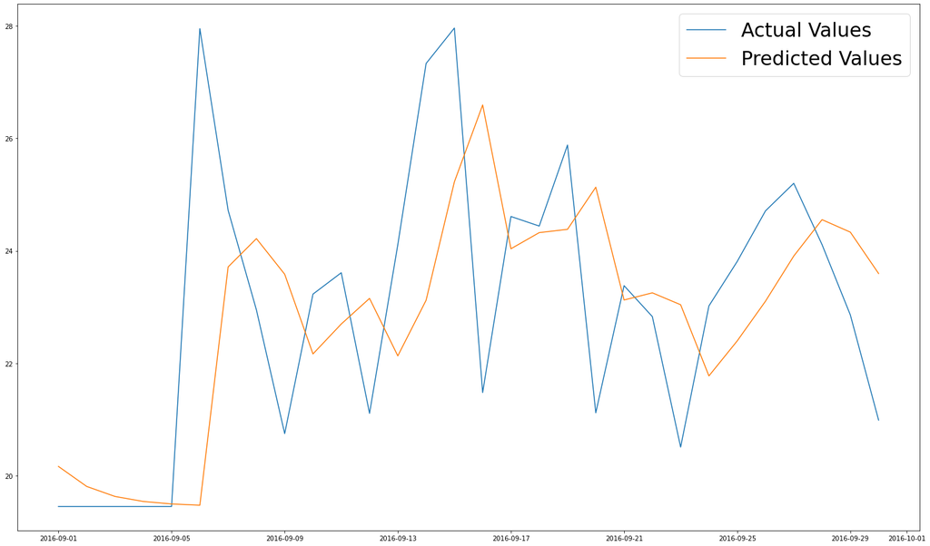

```python
# Plot results
plt.figure(figsize=(25,15))
plt.plot(df_train[-30:], label='Actual Values')
plt.plot(exp_smoothing_prediction, label = 'Predicted Values')
plt.legend(loc='best', prop={'size':30})
plt.show()
```

```python
# Forecasting using Exponential Smooething model
exp_smoothing_forecast = exp_smoothing_result.forecast(df_test.shape[0])
```

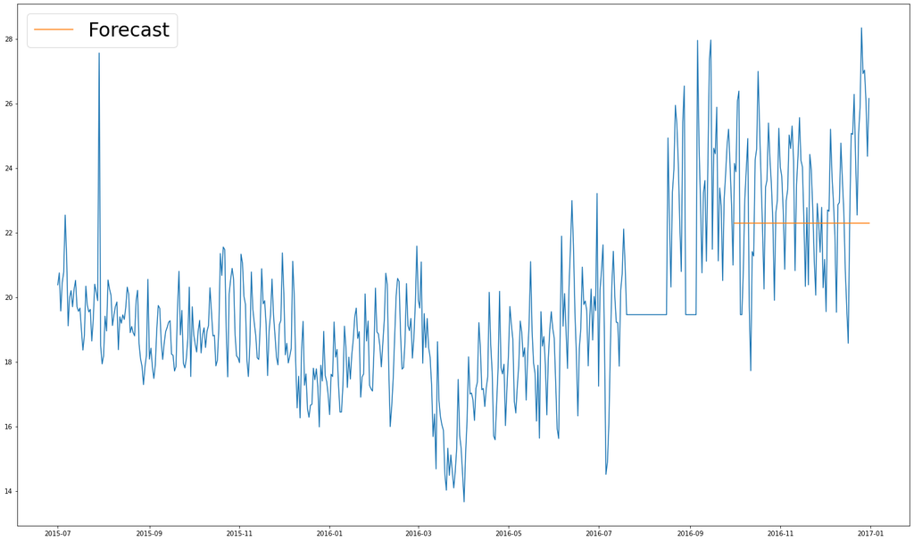

```python
#Plot Forecast Results
plt.figure(figsize=(25,15))

plt.plot(df_NoOut)
plt.plot(exp_smoothing_forecast, label='Forecast')
plt.legend(loc='best', prop={'size':30})
plt.show()
```

```python
# Check Accuracy
rmse_Exp_Smooth = 'Exponential Smoothing', str(np.sqrt(np.mean(np.square(exp_smoothing_forecast.values - df_test.Visits.values))))
rmse_values.append(rmse_Exp_Smooth)
rmse_Exp_Smooth
```

```
('Exponential Smoothing', '2.3053483092546174')
```

# Auto Arima

```python
# Train Model
auto_arima_model = auto_arima(df_train, start_p=2,max_p=7,start_q=2,max_q=7, m=1,stationary=False, trace=True, seasonal=False, error_action='ignore', suppress_warnings=True)
auto_arima_model.fit(df_train)
```

```
Performing stepwise search to minimize aic
 ARIMA(2,1,2)(0,0,0)[0] intercept   : AIC=inf, Time=0.83 sec
 ARIMA(0,1,0)(0,0,0)[0] intercept   : AIC=1718.666, Time=0.02 sec
 ARIMA(1,1,0)(0,0,0)[0] intercept   : AIC=1698.899, Time=0.04 sec
 ARIMA(0,1,1)(0,0,0)[0] intercept   : AIC=1673.053, Time=0.06 sec
 ARIMA(0,1,0)(0,0,0)[0]             : AIC=1716.666, Time=0.02 sec
 ARIMA(1,1,1)(0,0,0)[0] intercept   : AIC=1613.173, Time=0.16 sec
 ARIMA(2,1,1)(0,0,0)[0] intercept   : AIC=1611.624, Time=0.18 sec
 ARIMA(2,1,0)(0,0,0)[0] intercept   : AIC=1690.852, Time=0.06 sec
 ARIMA(3,1,1)(0,0,0)[0] intercept   : AIC=1599.916, Time=0.18 sec
 ARIMA(3,1,0)(0,0,0)[0] intercept   : AIC=1660.186, Time=0.07 sec
 ARIMA(4,1,1)(0,0,0)[0] intercept   : AIC=1599.053, Time=0.18 sec
 ARIMA(4,1,0)(0,0,0)[0] intercept   : AIC=1636.807, Time=0.10 sec
 ARIMA(5,1,1)(0,0,0)[0] intercept   : AIC=1594.367, Time=0.18 sec
 ARIMA(5,1,0)(0,0,0)[0] intercept   : AIC=1611.912, Time=0.11 sec
 ARIMA(6,1,1)(0,0,0)[0] intercept   : AIC=1570.508, Time=0.39 sec
 ARIMA(6,1,0)(0,0,0)[0] intercept   : AIC=1572.447, Time=0.14 sec
 ARIMA(7,1,1)(0,0,0)[0] intercept   : AIC=1572.156, Time=0.40 sec
 ARIMA(6,1,2)(0,0,0)[0] intercept   : AIC=1572.383, Time=0.46 sec
 ARIMA(5,1,2)(0,0,0)[0] intercept   : AIC=inf, Time=0.76 sec
 ARIMA(7,1,0)(0,0,0)[0] intercept   : AIC=1570.218, Time=0.14 sec
 ARIMA(7,1,0)(0,0,0)[0]             : AIC=1568.295, Time=0.10 sec
 ARIMA(6,1,0)(0,0,0)[0]             : AIC=1570.542, Time=0.08 sec
 ARIMA(7,1,1)(0,0,0)[0]             : AIC=1570.230, Time=0.22 sec
 ARIMA(6,1,1)(0,0,0)[0]             : AIC=1568.591, Time=0.20 sec

Best model:  ARIMA(7,1,0)(0,0,0)[0]
Total fit time: 7.551 seconds
```

```
ARIMA(order=(7, 1, 0), scoring_args={}, suppress_warnings=True,
      with_intercept=False)
```

```python
# Predict And Forecast
auto_arima_forecast = auto_arima_model.predict(n_period=df_test.shape[0])
auto_arima_forecast = pd.DataFrame(auto_arima_forecast, index = df_test.index, columns=['Forecast'])
```

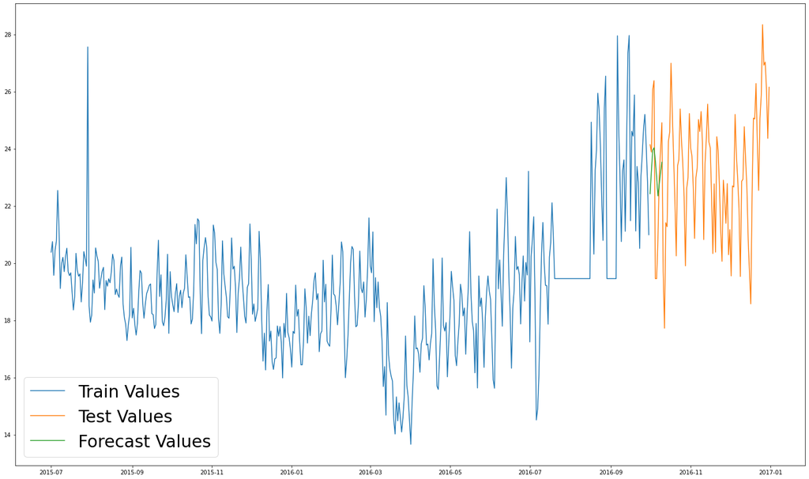

```python
# Plot Results
plt.figure(figsize=(25,15))
plt.plot(df_train, label='Train Values')
plt.plot(df_test, label = 'Test Values')
plt.plot(auto_arima_forecast, label='Forecast Values')
plt.legend(loc='best', prop={'size':30})
plt.show()
```

```python
# Check Accuracy
rmse_Auto_Arima = 'Auto Arima', str(np.sqrt(np.mean(np.square(exp_smoothing_forecast.values - df_test.Visits.values))))
rmse_values.append(rmse_Auto_Arima)
rmse_Auto_Arima
```

```
('Auto Arima', '2.3053483092546174')
```